# ClassNotes

Robert Stroud

10/1/2018

## R Markdown

Supervised Learning: y - repsonse, dependent x - predictors, independent, inputs

use a scatterplot to compare two numeric variables.

Describe three things

Form - linear / non linear ex. Direction - positive / negative Strength - Strong, moderate, weak ex. most subjective of the three.

When creating function to model some data, explanation and prediction are potential focuses. Prediction is significantly more useful than explanation.

an estimation funciton will have a carat/hat above it. ex. y = f(x) + Error, f(x) is the signal, error is the noise.

We want to minimize the noise.

Ei = y - f(x)

wnat to minimize the sum of squares error.

f(x) = y = b_0 + b_1(X_i) b_0 - y intercept b_1 - slope

sum of squares = Sum of (y_i - b_0 - b_iX_i)^2

take the derivative of above.

set it to zero solve for whatever term was used for derivative.

it ends up being in repsect to b_0 b_0 = avg(y) - b_1*avg(x) b_1 = sum of (x_1 - avg(x))(y_i - avg(y)) / sum of (x_i - avg(x))^2

these two equations result in the minimization of the sum of square eirs.

r - correlation coefficient -1 < r < 1 perfect negative relationship will be a -1. perfect postive relationship will be 1.

```r
library(MASS)
library(dplyr)
```

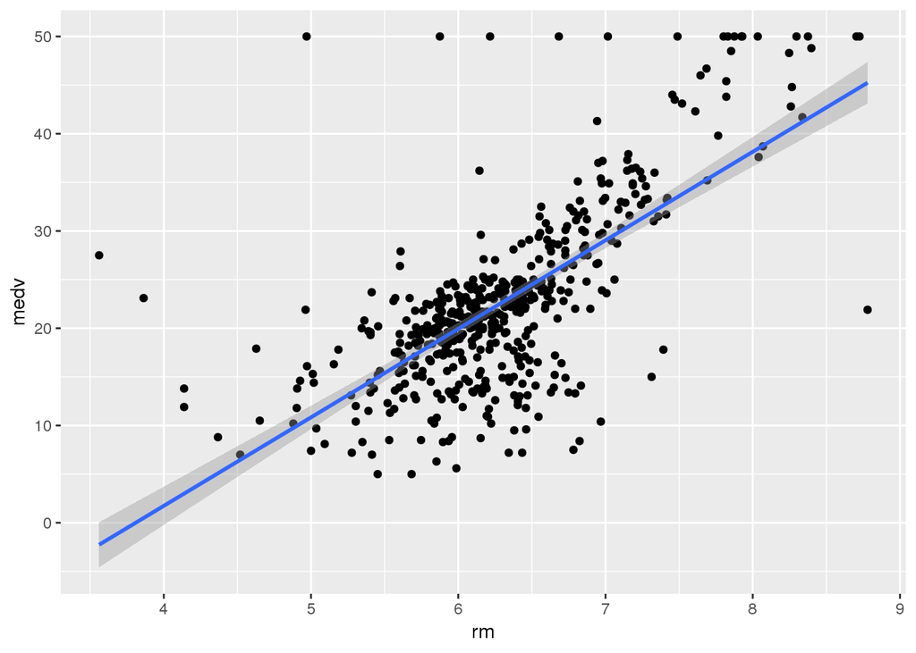

```r
library(ggplot2)
?Boston
##geom smooth used to give a linear model, lm stands for linear model.
## cor() is the method to find the correlation coefficient.
##lm(response ~ predictors, data = DF), this describe data, give intercpet and slope.
## sumamry of mod gives several values incuding r squared. taking the sqrt of that will give the correlation coeffiecient.

ggplot(Boston, aes(x = rm, y = medv)) + geom_point() + geom_smooth(method = "lm")
```

```r
cor(Boston$medv, Boston$rm)
```

```
## [1] 0.6953599
```

```r
mod <- lm(medv ~ rm, data = Boston)
mod
```

```
##
## Call:
## lm(formula = medv ~ rm, data = Boston)
##
## Coefficients:
## (Intercept)           rm
##     -34.671        9.102
```

```r
summary(mod)
```

```
##
## Call:
## lm(formula = medv ~ rm, data = Boston)
##
## Residuals:
##     Min      1Q  Median      3Q     Max
## -23.346  -2.547   0.090   2.986  39.433
##
## Coefficients:
##             Estimate Std. Error t value Pr(>|t|)
## (Intercept)  -34.671      2.650  -13.08   <2e-16 ***
## rm             9.102      0.419   21.72   <2e-16 ***
## ---
## Signif. codes:  0 '***' 0.001 '**' 0.01 '*' 0.05 '.' 0.1 ' ' 1
##
## Residual standard error: 6.616 on 504 degrees of freedom
## Multiple R-squared:  0.4835, Adjusted R-squared:  0.4825
## F-statistic: 471.8 on 1 and 504 DF,  p-value: < 2.2e-16
```

```r
summary(mod)$r.squared
```

```
## [1] 0.4835255
```

```r
library(ISLR)
##regress balance, putting a one after the . will do regress over intercept.
mod2 <- lm(Balance~., data = Credit)
```